# Part 8: Loss Reserving

# An Introduction to the ChainLadder package

A package developed by Markus Gesmann, an actuary at Lloyd’s, with several contributors. From the description file:

> Various statistical methods and models which are typically used for the estimation of outstanding claims reserves in general insurance, including those to estimate the claims development result as required under Solvency II.

# Load some data

Load Sch P data from http://www.casact.org/research/index.cfm?fa=loss_reserves_data

```r
data(othliab, package = 'raw')
names(othliab)
```

```
##  [1] "GRCODE"             "GRNAME"             "AccidentYear"
##  [4] "DevelopmentYear"    "DevelopmentLag"     "IncurLoss_h1"
##  [7] "CumPaidLoss_h1"     "BulkLoss_h1"        "EarnedPremDIR_h1"
## [10] "EarnedPremCeded_h1" "EarnedPremNet_h1"   "Single"
## [13] "PostedReserve97_h1"
```

# Fields in othliab

| Field | Description |
| --- | --- |
| GRCODE | NAIC company code (including insurer groups and single insurers) |
| GRNAME | NAIC company name (including insurer groups and single insurers) |
| AccidentYear | Accident year(1988 to 1997) |
| DevelopmentYear | Development year (1988 to 1997) |
| DevelopmentLag | Development year (AY-1987 + DY-1987 - 1) |
| IncurLoss_h1 | Incurred losses and allocated expenses reported at year end |
| CumPaidLoss_h1 | Cumulative paid losses and allocated expenses at year end |
| BulkLoss_h1 | Bulk and IBNR reserves on net losses and defense and cost containment expenses reported at year end |
| PostedReserve97_h1 | Posted reserves in year 1997 taken from the Underwriting and Investment Exhibit - Part 2A, including net losses unpaid and unpaid loss adjustment expenses |
| EarnedPremDIR_h1 | Premiums earned at incurral year - direct and assumed |
| EarnedPremCeded_h1 | Premiums earned at incurral year - ceded |
| EarnedPremNet_h1 | Premiums earned at incurral year - net |
| Single | 1 indicates a single entity, 0 indicates a group insurer |

# Recap

Take a moment to invesitgate the data yourself. Some suggestions…

```r
# What GROUPs are here?
sort(unique(othliab$GRNAME))
```

- How many groups are there?
- What is a unique key on the data? How can one prove it?
- How would you calculate the total premium for ASL 17 by accident year?

# Answers

```r
# How many groups are there?
length(unique(othliab$GRNAME))
```

```
## [1] 236
```

```r
# What is a unique key on the data?
nrow(othliab)
```

```
## [1] 23900
```

```r
nrow(unique(othliab[, c('GRCODE', 'AccidentYear', 'DevelopmentYear')]))
```

```
## [1] 23900
```

```r
nrow(unique(othliab[, c('GRCODE', 'AccidentYear', 'DevelopmentLag')]))
```

```
## [1] 23900
```

```r
table(othliab[, c('AccidentYear', 'DevelopmentYear')])
```

```
##             DevelopmentYear
## AccidentYear 1988 1989 1990 1991 1992 1993 1994 1995 1996 1997 1998 1999
##         1988  239  239  239  239  239  239  239  239  239  239    0    0
##         1989    0  239  239  239  239  239  239  239  239  239  239    0
##         1990    0    0  239  239  239  239  239  239  239  239  239  239
##         1991    0    0    0  239  239  239  239  239  239  239  239  239
##         1992    0    0    0    0  239  239  239  239  239  239  239  239
##         1993    0    0    0    0    0  239  239  239  239  239  239  239
##         1994    0    0    0    0    0    0  239  239  239  239  239  239
##         1995    0    0    0    0    0    0    0  239  239  239  239  239
##         1996    0    0    0    0    0    0    0    0  239  239  239  239
##         1997    0    0    0    0    0    0    0    0    0  239  239  239
##             DevelopmentYear
## AccidentYear 2000 2001 2002 2003 2004 2005 2006
##         1988    0    0    0    0    0    0    0
##         1989    0    0    0    0    0    0    0
##         1990    0    0    0    0    0    0    0
##         1991  239    0    0    0    0    0    0
##         1992  239  239    0    0    0    0    0
##         1993  239  239  239    0    0    0    0
##         1994  239  239  239  239    0    0    0
##         1995  239  239  239  239  239    0    0
##         1996  239  239  239  239  239  239    0
##         1997  239  239  239  239  239  239  239
```

```r
# How would you calculate the total premium for ASL 17 by accident year?
aggregate(
  data = othliab[othliab$DevelopmentYear == 1997, ],
  EarnedPremDIR_h1 ~ AccidentYear,
  FUN = sum
)
```

```
##    AccidentYear EarnedPremDIR_h1
## 1          1988           699282
## 2          1989           739075
## 3          1990           784273
## 4          1991           833930
## 5          1992           868809
## 6          1993           950941
## 7          1994          1055864
## 8          1995          1173617
## 9          1996          1233446
## 10         1997          1246770
```

What questions did you ask?

# Clean up the data

Aggregate and clean up the data a little.

```r
asl17 <- aggregate(
  x = othliab[, c("IncurLoss_h1", "CumPaidLoss_h1", "BulkLoss_h1", "EarnedPremDIR_h1")],
  by = othliab[, c('AccidentYear', 'DevelopmentYear', 'DevelopmentLag')],
  FUN = sum
)
names(asl17)
```

```
## [1] "AccidentYear"     "DevelopmentYear"  "DevelopmentLag"
## [4] "IncurLoss_h1"     "CumPaidLoss_h1"   "BulkLoss_h1"
## [7] "EarnedPremDIR_h1"
```

```r
names(asl17) <- c("AY", "DY", "Dev", "UltLoss", "PdLoss", "IBNR", "GPE")
asl17$IncLoss <- asl17$UltLoss - asl17$IBNR
```

# Make triangles using `ChainLadder::as.triangle`

Origin is the row names of the triangle Dev is the column names of the triangle

```r
tri.inc <- as.triangle(
  asl17[asl17$DY <= 1997, ],
  origin = 'AY',
  dev = 'Dev',
  value = 'IncLoss'
)
tri.pd <- as.triangle(
  asl17[asl17$DY <= 1997, ],
  origin = 'AY',
  dev = 'Dev',
  value = 'PdLoss'
)
tri.gpe <- as.triangle(
  asl17[asl17$DY <= 1997, ],
  origin = 'AY',
  dev = 'Dev',
  value = 'GPE'
)
tri.os <- tri.inc - tri.pd
```

# Investigate results

```r
tri.os
```

```
##       Dev
## AY          1      2      3      4     5     6     7     8    9   10
##   1988  97300 108468  94373  62945 40838 26704 13223  8391 4569 1670
##   1989  98546 108989  92717  65624 40526 21205 13254  4358 2561   NA
##   1990 111365 130010 107092  86152 56456 30095 19710 11060   NA   NA
##   1991 112781 139438 129647  83773 54231 40286 34628    NA   NA   NA
##   1992 120936 142244 124814  76950 73818 61971    NA    NA   NA   NA
##   1993 142826 185507 138371  98162 69672    NA    NA    NA   NA   NA
##   1994 156337 182068 190553 179355    NA    NA    NA    NA   NA   NA
##   1995 173361 183455 149940     NA    NA    NA    NA    NA   NA   NA
##   1996 174532 187729     NA     NA    NA    NA    NA    NA   NA   NA
##   1997 166379     NA     NA     NA    NA    NA    NA    NA   NA   NA
```

Etc.

# Mack Chain Ladder

- Uses “chain ladder” methods
- Predicts ultimates and standard errors
- Several parameters to customize analysis
- Standard error method: http://www.actuaries.org/LIBRARY/ASTIN/vol29no2/361.pdf

```r
MackChainLadder <- function (
  Triangle,
  weights = 1,
  alpha = 1,
  est.sigma = "log-linear",
  tail = FALSE,
  tail.se = NULL,
  tail.sigma = NULL,
  mse.method = "Mack") {...}
```

# Parameters

| Parameter | Notes |
| --- | --- |
| Triangle | the cumulative loss triangle |
| alpha | it is the ratio used in the prediction of ultimate values, alpha = 1 (default) is the chain ladder ratio, alpha = 0 is the simple average of the development ratios, and alpha = 2 is the weighted avera… |
| weights | a triangle of weights |
| tail | If tail = FALSE no tail factor will be applied (default), if tail=TRUE a tail factor will be estimated via a linear extrapolation of log(chainladderratios - 1), if tail is a numeric value(>1) then thi… |
| … | see ?ChainLadder for others |

# Default example

```r
MackChainLadder(tri.inc)
```

```
## MackChainLadder(Triangle = tri.inc)
##
##       Latest Dev.To.Date Ultimate    IBNR Mack.S.E CV(IBNR)
## 1988 319,559       1.000  319,559       0        0      NaN
## 1989 353,245       0.999  353,714     469    1,839    3.918
## 1990 372,163       0.987  376,891   4,728    3,400    0.719
## 1991 460,713       0.982  469,139   8,426    4,862    0.577
## 1992 451,221       0.958  470,878  19,657    7,850    0.399
## 1993 504,667       0.922  547,386  42,719   12,602    0.295
## 1994 581,599       0.865  672,339  90,740   21,880    0.241
## 1995 444,272       0.758  586,159 141,887   28,372    0.200
## 1996 378,987       0.590  642,261 263,274   42,193    0.160
## 1997 220,509       0.356  619,232 398,723   58,959    0.148
##
##                 Totals
## Latest:   4,086,935.00
## Dev:              0.81
## Ultimate: 5,057,557.97
## IBNR:       970,622.97
## Mack.S.E     98,436.45
## CV(IBNR):         0.10
```

Try `tri.pd` and `tri.gpe` yourself.

# Plot works, too

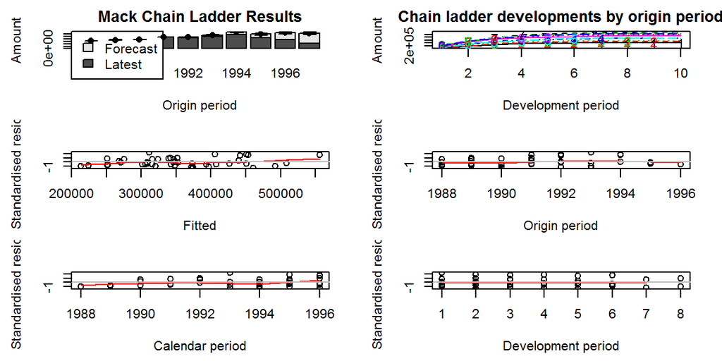

```r
plot(MackChainLadder(tri.inc))
```

# What plot shows

Plots six different graphs

1. Mack Chain Ladder Results
2. Chain ladder developments by origin period
3. Standardised residuals by Fitted value
4. Standardised residuals by Origin Period
5. Standardised residuals by Calendar period
6. Standardised residuals by Development period

The residual plots should be scattered with no pattern or direction for Mack’s method of calculating the standard error to apply. Patterns could be a result of a trend that should be investigated further. For more information see http://www.casact.org/pubs/proceed/proceed00/00245.pdf.

# Plot a triangle

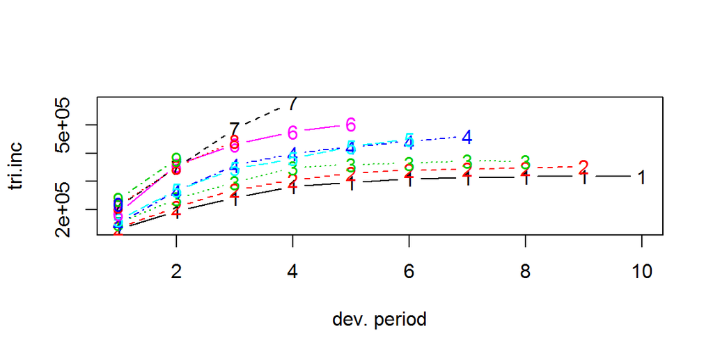

```r
plot(tri.inc)
```

# Different Ratios

```r
MackChainLadder(tri.inc, alpha = 0)$f   # Simple average of the dev ratios
```

```
##  [1] 1.650520 1.282821 1.141173 1.065571 1.038138 1.023460 1.005791
##  [8] 1.011152 1.001329 1.000000
```

```r
MackChainLadder(tri.inc, alpha = 1)$f   # Chain Ladder ratio ("loss wtd average")
```

```
##  [1] 1.657065 1.284461 1.141304 1.065801 1.039370 1.024821 1.005513
##  [8] 1.011361 1.001329 1.000000
```

```r
MackChainLadder(tri.inc, alpha = 2)$f   # Wtd Average of the dev ratios
```

```
##  [1] 1.661057 1.285341 1.142698 1.065855 1.040688 1.026294 1.005232
##  [8] 1.011568 1.001329 1.000000
```

# Different Tails

```r
MackChainLadder(tri.inc)$tail
```

```
## [1] FALSE
```

```r
MackChainLadder(tri.inc, tail = 1.1)$tail
```

```
## [1] 1.1
```

```r
MackChainLadder(tri.inc, tail = TRUE)$tail
```

```
## $tail.factor
## [1] 1.002256
##
## $tail.model
##
## Call:
## lm(formula = log(f - 1) ~ fn)
##
## Coefficients:
## (Intercept)           fn
##      0.2073      -0.6990
```

# Use weights to remove points from development

```r
w <- matrix(1, nrow = 10, ncol = 10)
w[3, 4] <- 0

MackChainLadder(tri.inc)
```

```
## MackChainLadder(Triangle = tri.inc)
##
##       Latest Dev.To.Date Ultimate    IBNR Mack.S.E CV(IBNR)
## 1988 319,559       1.000  319,559       0        0      NaN
## 1989 353,245       0.999  353,714     469    1,839    3.918
## 1990 372,163       0.987  376,891   4,728    3,400    0.719
## 1991 460,713       0.982  469,139   8,426    4,862    0.577
## 1992 451,221       0.958  470,878  19,657    7,850    0.399
## 1993 504,667       0.922  547,386  42,719   12,602    0.295
## 1994 581,599       0.865  672,339  90,740   21,880    0.241
## 1995 444,272       0.758  586,159 141,887   28,372    0.200
## 1996 378,987       0.590  642,261 263,274   42,193    0.160
## 1997 220,509       0.356  619,232 398,723   58,959    0.148
##
##                 Totals
## Latest:   4,086,935.00
## Dev:              0.81
## Ultimate: 5,057,557.97
## IBNR:       970,622.97
## Mack.S.E     98,436.45
## CV(IBNR):         0.10
```

```r
MackChainLadder(tri.inc, weights = w)
```

```
## MackChainLadder(Triangle = tri.inc, weights = w)
##
##       Latest Dev.To.Date Ultimate    IBNR Mack.S.E CV(IBNR)
## 1988 319,559       1.000  319,559       0        0      NaN
## 1989 353,245       0.999  353,714     469    1,827    3.893
## 1990 372,163       0.987  376,891   4,728    3,393    0.718
## 1991 460,713       0.982  469,139   8,426    4,855    0.576
## 1992 451,221       0.958  470,878  19,657    7,846    0.399
## 1993 504,667       0.922  547,386  42,719   12,599    0.295
## 1994 581,599       0.860  676,565  94,966   21,080    0.222
## 1995 444,272       0.753  589,842 145,570   27,929    0.192
## 1996 378,987       0.586  646,297 267,310   42,002    0.157
## 1997 220,509       0.354  623,123 402,614   59,015    0.147
##
##                 Totals
## Latest:   4,086,935.00
## Dev:              0.81
## Ultimate: 5,073,394.52
## IBNR:       986,459.52
## Mack.S.E     98,155.11
## CV(IBNR):         0.10
```

# Munich Chain Ladder

- Uses paid and incurred triangles to predict ultimates
- For details see http://www.variancejournal.org/issues/02-02/266.pdf

```r
MunichChainLadder <- function(
  Paid,
  Incurred,
  est.sigmaP = "log-linear",
  est.sigmaI = "log-linear",
  tailP = FALSE,
  tailI = FALSE
) {...}
```

# Munich Chain Ladder example

```r
MunichChainLadder(tri.pd, tri.inc)
```

```
## MunichChainLadder(Paid = tri.pd, Incurred = tri.inc)
##
##      Latest Paid Latest Incurred Latest P/I Ratio Ult. Paid Ult. Incurred
## 1988     317,889         319,559            0.995   317,889       319,559
## 1989     350,684         353,245            0.993   354,261       353,594
## 1990     361,103         372,163            0.970   372,879       377,542
## 1991     426,085         460,713            0.925   455,806       472,434
## 1992     389,250         451,221            0.863   447,235       478,919
## 1993     434,995         504,667            0.862   536,888       548,906
## 1994     402,244         581,599            0.692   627,089       705,766
## 1995     294,332         444,272            0.663   569,891       586,097
## 1996     191,258         378,987            0.505   619,932       627,253
## 1997      54,130         220,509            0.245   601,372       626,851
##      Ult. P/I Ratio
## 1988          0.995
## 1989          1.002
## 1990          0.988
## 1991          0.965
## 1992          0.934
## 1993          0.978
## 1994          0.889
## 1995          0.972
## 1996          0.988
## 1997          0.959
##
## Totals
##                Paid  Incurred P/I Ratio
## Latest:   3,221,970 4,086,935      0.79
## Ultimate: 4,903,242 5,096,921      0.96
```

# Plot Munich Chain Ladder

```r
# [ALR Dec 13, 2016]
# How to get past error "figure margins too large"
#
#   plot(MunichChainLadder(tri.pd, tri.inc))
#
```